# Third Week: Exploratory Data Analysis

Alaleh Ahmadian Shalchi

February 21, 2018

```r
library(dplyr)
library(engsoccerdata)
library(shiny)
library(highcharter)
library(ggplot2)
spain = as.data.frame(spain)
All_seasons = sort(unique(spain$Season))
All_Teams = unique(spain$home)
Championships <- data.frame(cteam=unique(spain$home),point=as.vector(matrix(0,nrow=61)), stringsAsFactors=FALSE)
Team_goals = data.frame(cteam=unique(spain$home),goals_scored=as.vector(matrix(0,nrow=61)),goals_conceded=as.vector(matrix(0,nrow=61)), stringsAsFactors=FALSE)
```

Function get_rankings_by_time works by getting a season and an end date then gives the data of the games played in league and scores up until that day

count_points determines how many points a team should get based on result of the game

get_rankings gives full table data for a season

```r
## Functions

team_rankings_by_time <- function (season=NULL, end = NULL)
{
  GA <- GF <- ga <- gf <- gd <- GD <- D <- L <- W <- Pts <- . <- Date <- home <- team <- visitor <- hgoal <- opp <- vgoal <- goaldif <- FT <- division <- result <- maxgoal <- mingoal <- absgoaldif <- NULL
  spainx <- spain[(spain$Season == season), ]
  spainx <- spainx[(spainx$Date <= end), ]

  temp <- rbind(dplyr::select(spainx, team = home, opp = visitor,
                                GF = hgoal, GA = vgoal), dplyr::select(spainx, team = visitor,
                                opp = home, GF = vgoal, GA = hgoal))
  temp <- temp %>% dplyr::mutate(GD = GF - GA) %>% dplyr::group_by(team) %>%
    dplyr::summarise(GP = sum(GD <= 100), W = sum(GD > 0),
                     D = sum(GD == 0), L = sum(GD < 0), gf = sum(GF),
                     ga = sum(GA), gd = sum(GD)) %>% dplyr::mutate(Pts = (W *
                    3) + D) %>% dplyr::arrange(-Pts, -gd, -gf) %>% dplyr::mutate(Pos = rownames(.)) %>%
    as.data.frame()
  return(temp)
}

count_points = function(GoalsD){
  result = vector(mode = typeof(GoalsD[1]), length = length(GoalsD))
  for (i in 1:length(GoalsD)){
    if (GoalsD[i]>0){result[i]=3}
    else if (GoalsD[i]==0){result[i]=1}
    else{result[i]=0}}
  return(result)
}

get_rankings <- function (df = spain, Season, pts) {

  Goals_Conceded <- Goals_Scored <- Goals_Conceded <- Goals_Scored <- Goal_Difference <- Goal_Difference <- D <- L <- W <- Pts <- . <- Date <- home <- team <- visitor <- hgoal <- opp <- vgoal <- goaldif <- FT <- division <- result <- maxgoal <- mingoal <- absgoaldif <- NULL
  spainx <- df[(df$Season == Season), ]
  ans <- rbind(spainx %>% dplyr::select(team = home, opp = visitor,
                                        Goals_Scored = hgoal, Goals_Conceded = vgoal),
               spainx %>% dplyr::select(team = visitor, opp = home,
                                        Goals_Scored = vgoal, Goals_Conceded = hgoal)) %>% dplyr::mutate(Goal_Difference = Goals_Scored - Goals_Conceded) %>% dplyr::group_by(team) %>% dplyr::summarise(Goals_Concededmes_Played = sum(Goal_Difference <= 100), W = sum(Goal_Difference > 0), D = sum(Goal_Difference == 0), L = sum(Goal_Difference < 0), Goals_Scored = sum(Goals_Scored), Goals_Conceded = sum(Goals_Conceded),Goal_Difference = sum(Goal_Difference)) %>%
    dplyr::mutate(Pts = (W *  pts) + D) %>%
    dplyr::arrange(-Pts, -Goal_Difference, -Goals_Scored) %>%
    dplyr::mutate(Pos = rownames(.)) %>% as.data.frame()
  return(ans)

}
```

## Problem 1

We sum score of each team then compute goal difference and goals scored and sort the data by these three

```r
Champion_times = data.frame(Team=All_Teams, num=rep(0,length(All_Teams)), stringsAsFactors=FALSE)
season_champ = data.frame(season=All_seasons, winner=NA)

for (cur_season in 1:length(All_seasons)){

  if (All_seasons[cur_season]<1996){rankings_df = get_rankings(spain,All_seasons[cur_season],2)}
  else{rankings_df = get_rankings(spain,All_seasons[cur_season],3)}

  cur_champ = rankings_df[which(rankings_df$Pos==1),]$team
  Champion_times[which(Champion_times$Team==cur_champ),]$num = Champion_times[which(Champion_times$Team==cur_champ),]$num + 1
  season_champ$winner[season_champ$season==All_seasons[cur_season]] = cur_champ

}

Champion_times = Champion_times[with(Champion_times,order(-num)),]

highchart() %>%
  hc_chart(type = "column") %>%
  hc_title(text = "Most La liga Championships") %>%
  hc_xAxis(categories = Champion_times$Team[1:9]) %>%
  hc_add_series(data = Champion_times$num[1:9],
                name = "Championships")
```

[interactive chart not shown]

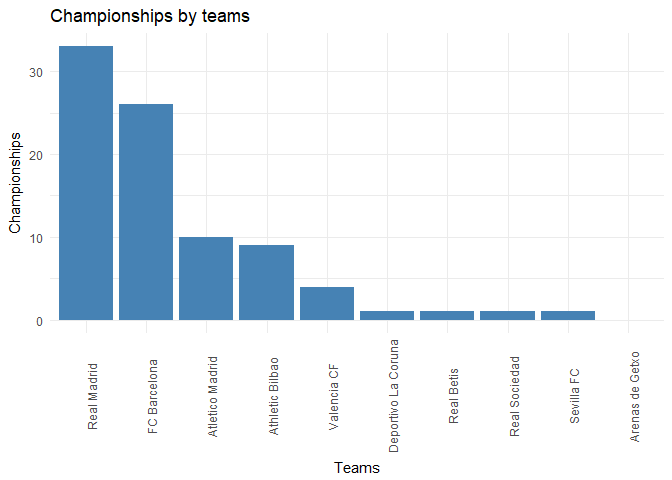

```r
ggplot(data=head(Champion_times,10), aes(x=reorder(Team,-num), y=num)) + geom_bar(stat="identity", fill="steelblue") + theme_minimal() +  theme(axis.text.x = element_text(angle=90)) + labs(x="Teams", y="Championships", title="Championships by teams")
```

## Problem 2

We define number_of_goals/number_of_Goals_Concededmes to be an identity of a boringness the less this number is the more boring that concept is. to make it easier to see I changed it to 5-number_of_goals/number_of_Goals_Concededmes so the most boring concept has the most boringness amount

```r
data.frame(spain %>% group_by(Season) %>% summarise(boredom=5-(sum(hgoal+vgoal)/length(Season)))) %>% arrange(-boredom) -> season_boringness
print(season_boringness[1,]$Season)
```

```
## [1] 1972
```

```r
data.frame(spain %>% group_by(home) %>% summarise(boredom=3-(sum(hgoal)/length(home)))) %>% arrange(-boredom) -> team_boringness
print(team_boringness[1,]$home)
```

```
## [1] "CD Logrones"
```

```r
highchart() %>%
  hc_chart(type = "line") %>%
  hc_title(text = "How boring spanish teams are") %>%
  hc_xAxis(categories = team_boringness$home[1:10]) %>%
  hc_add_series(data = team_boringness$boredom[1:10],
                name = "boringness") %>%  hc_add_theme(hc_theme_sandsignika())
```

[interactive chart not shown]

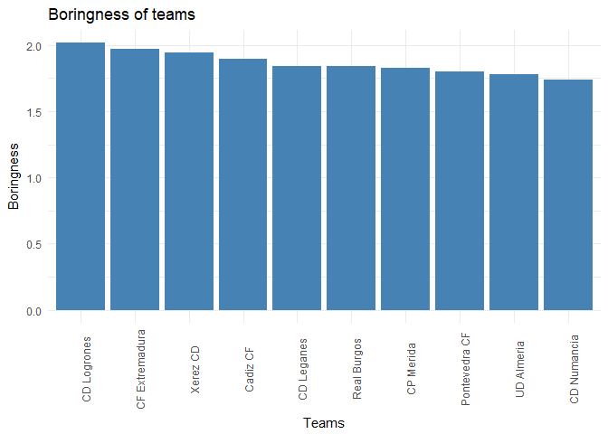

```r
ggplot(data=head(team_boringness,10), aes(x=reorder(home,-boredom), y=boredom)) + geom_bar(stat="identity", fill="steelblue") + theme_minimal() +  theme(axis.text.x = element_text(angle=90)) + labs(x="Teams", y="Boringness", title="Boringness of teams")
```

```r
highchart() %>%
  hc_chart(type = "line") %>%
  hc_title(text = "How boring spanish leagues are") %>%
  hc_xAxis(categories = season_boringness$Season[1:10]) %>%
  hc_add_series(data = season_boringness$boredom[1:10],
                name = "boringness")
```

[interactive chart not shown]

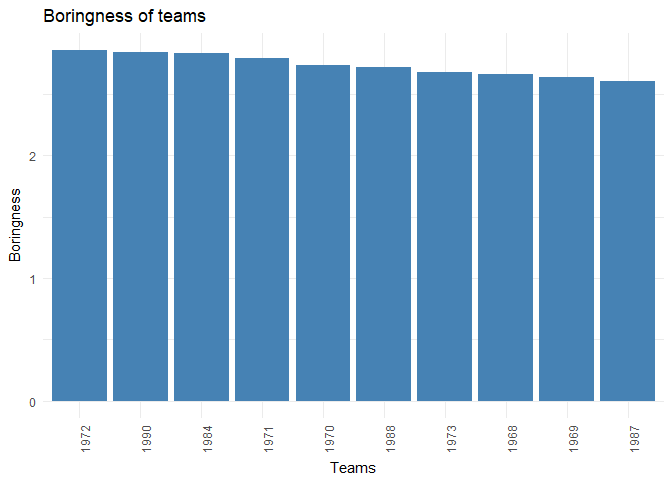

```r
ggplot(data=head(season_boringness,10), aes(x=reorder(Season,-boredom), y=boredom)) + geom_bar(stat="identity", fill="steelblue") + theme_minimal() +  theme(axis.text.x = element_text(angle=90)) + labs(x="Teams", y="Boringness", title="Boringness of teams")
```

## Problem 3

We have to separate first game between each two teams from the second one and count the points for that half-league, then compare it to season winner which we have from the first problem.

```r
All_seasons = sort(All_seasons)
ans = 0

for (this_season in 1:length(All_seasons)){

  season_games = filter(spain,Season==All_seasons[this_season])
  season_teams = unique(season_games$home)
  played_games = data.frame(expand.grid(season_teams,season_teams))
  names(played_games) = c("Home","Visitor")
  played_games$flag = FALSE
  season_games = season_games[order(season_games$Date),]
  half_season = season_games
  half_points = data.frame(team = season_teams, Points=0)

  for (game in 1:dim(season_games)[1]){
    cur_game = data.frame(season_games[game,])
    hp = cur_game$home
    vp = cur_game$visitor
    if (played_games$flag[(hp==played_games$Home & vp==played_games$Visitor)]==FALSE){
      played_games$flag[(hp==played_games$Visitor & vp==played_games$Home)] = TRUE
      half_season$tier[half_season$home==vp & half_season$visitor==hp] = NA
    }
  }
    half_season = half_season[!is.na(half_season$tier),]
    for (k in 1:dim(half_season)){
      g = half_season[k,]
      if (g$vgoal>g$hgoal){
        half_points$Points[half_points$team==g$visitor] = half_points$Points[half_points$team==g$visitor]+3
      }
      else if (g$vgoal<g$hgoal){
        half_points$Points[half_points$team==g$home] = half_points$Points[half_points$team==g$visitor]+3
      }
      else{
        half_points$Points[half_points$team==g$home] = half_points$Points[half_points$team==g$visitor]+1
        half_points$Points[half_points$team==g$visitor] = half_points$Points[half_points$team==g$visitor]+1
      }
    }

  half_points = half_points[order(-half_points$Points),]
  half_champ = as.character(half_points$team[1])
  if(season_champ$winner[season_champ$season==All_seasons[this_season]]==half_champ){ans = ans+1}
}

print(ans/length(All_seasons))
```

```
## [1] 0.1046512
```

## Problem 4

```r
game_data = filter(spain,(spain$Season>=2001 & spain$Season<=2010))
teams = unique(game_data$home)
game_wins = data.frame(expand.grid(winner = teams[!(teams %in% list("Real Madrid", "FC Barcelona", "Valencia CF", "Athletic Bilbao"))],loser = c("Real Madrid", "FC Barcelona", "Valencia CF", "Athletic Bilbao")))
game_wins$wins_against = rep(0,120)
game_wins$draws = rep(0,120)

for (i in 1:dim(game_data)[1]){

  cur_game = game_data[i,]
  home = cur_game$home
  visitor = cur_game$visitor
  if (cur_game$hgoal>cur_game$vgoal){
    game_wins$wins_against[(game_wins$winner==home & game_wins$loser==visitor)] = game_wins$wins_against[(game_wins$winner==home & game_wins$loser==visitor)] +1
  }
  else if (cur_game$hgoal<cur_game$vgoal){
    game_wins$wins_against[(game_wins$winner==visitor & game_wins$loser==home)] = game_wins$wins_against[(game_wins$winner==visitor & game_wins$loser==home)] +1
  }
  else if (cur_game$hgoal==cur_game$vgoal){
    game_wins$draws[(game_wins$winner==visitor & game_wins$loser==home)] = game_wins$draws[(game_wins$winner==visitor & game_wins$loser==home)] +1
  }
}

print(head(game_wins[order(-(game_wins$wins_against+game_wins$draws)),],30))
```

```
##                  winner           loser wins_against draws
## 100       Villarreal CF Athletic Bilbao           13     2
## 92  Deportivo La Coruna Athletic Bilbao           10     3
## 95           Sevilla FC Athletic Bilbao           13     0
## 93   Espanyol Barcelona Athletic Bilbao            8     4
## 70        Villarreal CF     Valencia CF            9     2
## 77     Racing Santander     Valencia CF            9     2
## 40        Villarreal CF    FC Barcelona            6     4
## 109     Atletico Madrid Athletic Bilbao            9     1
## 49      Atletico Madrid    FC Barcelona            7     2
## 65           Sevilla FC     Valencia CF            9     0
## 79      Atletico Madrid     Valencia CF            5     4
## 91         RCD Mallorca Athletic Bilbao            8     1
## 2   Deportivo La Coruna     Real Madrid            8     0
## 97           CA Osasuna Athletic Bilbao            5     3
```

[output cut: 16 more lines]

```r
## we could get max for each team one by one but I felt better seeing a table of results on this question
```

Black cat for Athletic Bilbao is Villareal FC with 13 wins and 2 draws black cat for Valencia FC is Racing Santander and Villarreal CF with 9 wins and 2 draws Black cat for Real Madrid is Deportivo La Coruna with 8 wins Black cat for FC Barcelona is Villareal CF with 6 wins and 4 draws

## Problem 5

We need to find the most difference between first and second team in ranking. the function, team_rankings_by_time gives us the ranking of teams up until the given date to the function so we just have to check the difference between first and second team at the end of each season

for fastest championship I splitted the Date into its components and sorted the games after each day, the first time a team has a big enough point that no other team can acess it, it’s declared champion

```r
team_rankings_by_time <- function (season=NULL, begin = NULL, end = NULL)
{
  GA <- GF <- ga <- gf <- gd <- GD <- D <- L <- W <- Pts <- . <- Date <- home <- team <- visitor <- hgoal <- opp <- vgoal <- goaldif <- FT <- division <- result <- maxgoal <- mingoal <- absgoaldif <- NULL
  spainx <- spain[(spain$Season == season), ]
  spainx <- spainx[(spainx$Date <= end), ]
  temp <- rbind(dplyr::select(spainx, team = home, opp = visitor,
                                GF = hgoal, GA = vgoal), dplyr::select(spainx, team = visitor,
                                opp = home, GF = vgoal, GA = hgoal))
  temp <- temp %>% dplyr::mutate(GD = GF - GA) %>% dplyr::group_by(team) %>%
    dplyr::summarise(GP = sum(GD <= 100), W = sum(GD > 0),
                     D = sum(GD == 0), L = sum(GD < 0), gf = sum(GF),
                     ga = sum(GA), gd = sum(GD)) %>% dplyr::mutate(Pts = (W *
                    3) + D) %>% dplyr::arrange(-Pts, -gd, -gf) %>% dplyr::mutate(Pos = rownames(.)) %>%
    as.data.frame()
  return(temp)
}

max_difference = -1
max_diff_team = ""

for(this_season in 1:length(All_seasons)){

  games_season = filter(spain,spain$Season==All_seasons[this_season])
  days_in_season = unique(games_season$Date)
  days_in_season = sort(days_in_season)

  rank_tbl = team_rankings_by_time(season=All_seasons[this_season],end=days_in_season[length(days_in_season)])
  first = rank_tbl$Pts[rank_tbl$Pos==1]
  second = rank_tbl$Pts[rank_tbl$Pos==2]
  diff = first-second
  if (diff>max_difference){
    max_difference = diff
    max_diff_team = as.character(rank_tbl$team[rank_tbl$Pos==1])
  }

}

print(max_diff_team)
```

```
## [1] "Real Madrid"
```

```r
print(paste0("difference of points between first and second team:"))
```

```
## [1] "difference of points between first and second team:"
```

```r
print(max_difference)
```

```
## [1] 21
```

```r
season_data = filter(spain,Season==1998)

half_season = season_data %>% group_by(Season) %>% mutate(y = substr(Date,1,4), m = substr(Date,6,7), d = substr(Date,9,10)) %>% select(1, y, m, d, 3:10) %>% arrange(y, m, d)
games_half = rbind(half_season %>% select(Season, y, m, d, Team=home, opp=visitor, GF=hgoal, GA=vgoal),half_season %>% select(Season, y, m, d, Team=visitor, opp=home, GF=vgoal, GA=hgoal)) %>% mutate (GD=GF-GA) %>% arrange(y, m, d)

games_half = games_half %>% mutate(scr=count_points(GD)) %>% mutate(temp=1) %>%
  group_by(Season, Team) %>% arrange(y,m,d) %>%
  mutate(Cumulative_Match = cumsum(temp)) %>%
  group_by(Season, Team) %>%
  mutate(all_matches=n(), matches_left=n()-Cumulative_Match)

games_half = games_half %>% mutate(scr=count_points(GD)) %>% mutate(temp=1) %>%
  group_by(Season, Team) %>% arrange(y,m,d) %>%
  mutate(Cumulative_Score=cumsum(scr), Cumulative_Match = cumsum(temp)) %>%
  group_by(Season, Team) %>% mutate(all_matches=n(), matches_left=n()-Cumulative_Match)
games_half= games_half %>% group_by(Season, matches_left) %>% arrange(-Cumulative_Score) %>%
  mutate(temp=1, cur_rank=cumsum(temp)) %>% arrange(Season, -matches_left, cur_rank)
games_half$adj_diff = vector(mode = typeof(1L), length = dim(games_half)[1])

for (i in 1:(dim(games_half)[1]-1))
{
  if (games_half$matches_left[i]==games_half$matches_left[i+1]){
  games_half$adj_diff[i]=games_half$Cumulative_Score[i]-games_half$Cumulative_Score[i+1]}
  else{games_half$adj_diff[i]=0}
}
games_half$adj_diff[dim(games_half)[1]]=0

games_half$adj_diff = as.integer(games_half$adj_diff)
games_half$cur_rank = as.integer(games_half$cur_rank)
games_half$matches_left = as.integer(games_half$matches_left)

games_half = games_half %>% filter(cur_rank==1 & adj_diff>(3*matches_left)) %>%
  mutate(fastness=100*matches_left/all_matches) %>%
  group_by(Season) %>% arrange(-fastness)%>% slice(1) %>% arrange(-fastness) %>%
  select(Season, Team, All_Matches=all_matches, Matches_Left=matches_left)

print(head(games_half,1))
```

```
## # A tibble: 1 x 4
## # Groups:   Season [1]
##   Season         Team All_Matches Matches_Left
##    <dbl>        <chr>       <int>        <int>
## 1   1998 FC Barcelona          38            3
```

## Problem 6

```r
lose_strike = data.frame(team = All_Teams, lose=rep(0,length(All_Teams)))
win_strike = data.frame(team = All_Teams, win=rep(0,length(All_Teams)))
draw_strike = data.frame(team = All_Teams, draw=rep(0,length(All_Teams)))
max_lose = max_draw = max_win = -1
max_lose_team = max_win_team = max_draw_team = ""

timed_games = spain[order(spain$Date),]

for (i in 1:dim(timed_games)[1]){

   cur_game = timed_games[i,]
   cur_home = cur_game$home
   cur_visitor = cur_game$visitor

   if (cur_game$hgoal>cur_game$vgoal) {

      win_strike$win[win_strike$team==cur_home] = win_strike$win[win_strike$team==cur_home]+1
      win_strike$win[win_strike$team==cur_visitor] = 0
      lose_strike$lose[lose_strike$team==cur_visitor]=lose_strike$lose[lose_strike$team==cur_visitor]+1
      lose_strike$lose[lose_strike$team==cur_home] = 0
      draw_strike$draw[draw_strike$team==cur_home] = 0
      draw_strike$draw[draw_strike$team==cur_visitor]= 0

   }

   if (cur_game$hgoal<cur_game$vgoal) {

      win_strike$win[win_strike$team==cur_visitor] = win_strike$win[win_strike$team==cur_visitor]+1
      win_strike$win[win_strike$team==cur_home] = 0
      lose_strike$lose[lose_strike$team==cur_home]=lose_strike$lose[lose_strike$team==cur_home]+1
      lose_strike$lose[lose_strike$team==cur_visitor] = 0
      draw_strike$draw[draw_strike$team==cur_home] = 0
      draw_strike$draw[draw_strike$team==cur_visitor]= 0

   }

  if (cur_game$hgoal==cur_game$vgoal) {

      win_strike$win[win_strike$team==cur_visitor] = 0
      win_strike$win[win_strike$team==cur_home] = 0
      lose_strike$lose[lose_strike$team==cur_home]= 0
      lose_strike$lose[lose_strike$team==cur_visitor] = 0
      draw_strike$draw[draw_strike$team==cur_home] = draw_strike$draw[draw_strike$team==cur_home]+1
      draw_strike$draw[draw_strike$team==cur_visitor]= draw_strike$draw[draw_strike$team==cur_visitor]+1

  }

  if(max_lose<max(lose_strike$lose)){
    max_lose = max(lose_strike$lose)
    max_lose_team = as.character(lose_strike$team[lose_strike$lose==max_lose])
  }
  if(max_draw<max(draw_strike$draw)){
    max_draw = max(draw_strike$draw)
    max_draw_team = as.character(draw_strike$team[draw_strike$draw==max_draw])
  }
  if(max_win<max(win_strike$win)){
    max_win = max(win_strike$win)
    max_win_team = as.character(win_strike$team[win_strike$win==max_win])
  }

}
print(paste0("win:"))
```

```
## [1] "win:"
```

```r
print(max_win_team)
```

```
## [1] "FC Barcelona"
```

```r
print(max_win)
```

```
## [1] 16
```

```r
print(paste0("draw:"))
```

```
## [1] "draw:"
```

```r
print(max_draw_team)
```

```
## [1] "Burgos CF"
```

```r
print(max_draw)
```

```
## [1] 9
```

```r
print(paste0("lose:"))
```

```
## [1] "lose:"
```

```r
print(max_lose_team)
```

```
## [1] "UD Las Palmas"
```

```r
print(max_lose)
```

```
## [1] 11
```

## Problem 7

using the function team_rankings_by_time we get table ranking for each season after each day and compute if a team is definitly going down fastness of falling is determined by games_left/games_of_season

```r
max_ratio = 0
max_team = ""


for(this_season in 40:55){

  games_season = filter(spain,spain$Season==All_seasons[this_season])
  teams_season = unique(games_season$home)
  team_num = length(teams_season)
  days_in_season = unique(games_season$Date)
  days_in_season = sort(days_in_season)

  for (j in 3:length(days_in_season)){
    cur_day = days_in_season[j]
    rank_tbl = team_rankings_by_time(season=All_seasons[this_season],end=cur_day)
    last = rank_tbl$Pts[team_num]
    not_last = rank_tbl$Pts[team_num-3]
    if (not_last>3 & !is.null(rank_tbl$GP[team_num]) & team_num>3 & not_last-last>3*(team_num*(team_num-1)-rank_tbl$GP[team_num]))
      if((team_num*(team_num-1)-(rank_tbl$GP[rank_tbl$Pos==team_num]))/(team_num*(team_num-1))>max_ratio)
        max_ratio = (team_num*(team_num-1)-rank_tbl$GP[rank_tbl$Pos==team_num])/(team_num)*(team_num-1)
        max_team = as.character(rank_tbl$team[rank_tbl$Pos==team_num])
  }
}
print(max_team)
```

```
## [1] "Celta Vigo"
```

## Problem 8

We sort the data by subsets of Date attribute and find the rank of each team for each week then use this data to draw a chart

```r
season_1998 = filter(spain,Season==1998)

half_season = season_1998 %>% group_by(Season) %>% mutate(y = substr(Date,1,4), m = substr(Date,6,7), d = substr(Date,9,10)) %>% select(1, y, m, d, 3:10) %>% arrange(y, m, d)

games_half = rbind(half_season %>% select(Season, y, m, d, Team=home, opp=visitor, GF=hgoal, GA=vgoal),half_season %>% select(Season, y, m, d, Team=visitor, opp=home, GF=vgoal, GA=hgoal)) %>% mutate (GD=GF-GA) %>% arrange(y, m, d)

games_half = games_half %>% mutate(scr=count_points(GD)) %>% mutate(temp=1) %>%
  group_by(Season, Team) %>% arrange(y,m,d) %>%
  mutate(Cumulative_GD=cumsum(GD), Cumulative_Score=cumsum(scr), CumMatch = cumsum(temp)) %>%
  group_by(Season, Team) %>% mutate(all_matches=n(), matches_left=n()-CumMatch)

games_half = games_half %>% group_by(Season, matches_left) %>% arrange(-Cumulative_Score, -Cumulative_GD) %>% mutate(temp=1, cur_rank=cumsum(temp)) %>% arrange(Season, -matches_left, cur_rank)

games_half = games_half %>% arrange(-matches_left, cur_rank)

hchart(games_half, "spline", hcaes(x=38-matches_left, y=cur_rank, group = Team)) %>%
  hc_yAxis(reversed=TRUE, title = list(text = "team rank")) %>%
  hc_xAxis(title = list(text = "Week"))
```

[interactive chart not shown]

## Problem 9

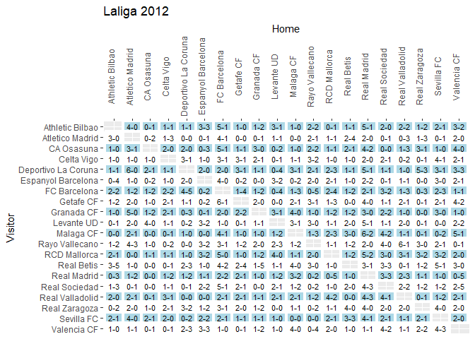

```r
game1 = filter(spain, Season == "2012")
fillframe = as.numeric(reorder(game1$visitor,desc(game1$visitor)))
fillframe = as.factor(ifelse(fillframe %% 2 == 0, 1, 0))

ggplot(game1, aes(home, reorder(visitor,desc(visitor)), fill = fillframe)) +
  geom_tile(color="white", size=1.5, stat="identity", height=1, width=1) +
  scale_fill_manual(values = c("white", "lightblue")) +
  geom_text(data=game1, aes(home, visitor, label = FT), size=rel(3)) +
  scale_x_discrete(position="top") + scale_y_discrete(expand = c(0, 0)) +
  xlab("Home") + ylab("Visitor") +
  ggtitle("Laliga 2012") +
  theme(legend.position = "None",
        axis.text.x = element_text(angle = 90),
        panel.border = element_rect(fill=NA,color="white", size=0.25, linetype="solid"))
```

## Problem 10

First part of statistic that seems interesting is do teams tend to win the game if they’ve won the half-time?

```r
types = c("win_win", "draw_draw", "lose_lose", "draw_lose", "lose_draw","draw_win", "win_draw", "lose_win", "win_lose")

HT_FT = data.frame(category=unique(types), count=rep(0,9), stringsAsFactors=FALSE)
spainrm = spain[!(is.na(spain$HT)), ]

for (i in 1:dim(spainrm)[1]){

  cur_game = spainrm[i,]
  if (substr(cur_game$HT,1,1)==substr(cur_game$HT,3,3)){
    if(cur_game$hgoal==cur_game$vgoal){
      HT_FT$count[HT_FT$category=="draw_draw"] = HT_FT$count[HT_FT$category=="draw_draw"]+1
    }
    else if(cur_game$hgoal>cur_game$vgoal){
      HT_FT$count[HT_FT$category=="draw_win"] = HT_FT$count[HT_FT$category=="draw_win"]+1
    }
    else if(cur_game$hgoal<cur_game$vgoal){
      HT_FT$count[HT_FT$category=="draw_lose"] = HT_FT$count[HT_FT$category=="draw_lose"]+1
    }
  }
  else if (substr(cur_game$HT,1,1)<substr(cur_game$HT,3,3)){
    if(cur_game$hgoal==cur_game$vgoal){
      HT_FT$count[HT_FT$category=="lose_draw"] = HT_FT$count[HT_FT$category=="lose_draw"]+1
    }
    else if(cur_game$hgoal>cur_game$vgoal){
      HT_FT$count[HT_FT$category=="lose_win"] = HT_FT$count[HT_FT$category=="lose_win"]+1
    }
    else if(cur_game$hgoal<cur_game$vgoal){
      HT_FT$count[HT_FT$category=="lose_lose"] = HT_FT$count[HT_FT$category=="lose_lose"]+1
    }
  }
  else if (substr(cur_game$HT,1,1)>substr(cur_game$HT,3,3)){
    if(cur_game$hgoal==cur_game$vgoal){
      HT_FT$count[HT_FT$category=="win_draw"] = HT_FT$count[HT_FT$category=="win_draw"]+1
    }
    else if(cur_game$hgoal>cur_game$vgoal){
      HT_FT$count[HT_FT$category=="win_win"] = HT_FT$count[HT_FT$category=="win_win"]+1
    }
    else if(cur_game$hgoal<cur_game$vgoal){
      HT_FT$count[HT_FT$category=="win_lose"] = HT_FT$count[HT_FT$category=="win_lose"]+1
    }
  }
}

print(HT_FT)
```

```
##    category count
## 1   win_win  8336
## 2 draw_draw  3494
## 3 lose_lose  2652
## 4 draw_lose  1792
## 5 lose_draw   915
## 6  draw_win  4012
## 7  win_draw  1073
## 8  lose_win   577
## 9  win_lose   304
```

```r
highchart() %>%
  hc_chart(type = "column") %>%
  hc_title(text = "half-time vs. full-time") %>%
  hc_xAxis(categories = HT_FT$category) %>%
  hc_add_series(data = HT_FT$count,
                name = "games")
```

[interactive chart not shown]

Looking over our whole data we see it’s more probable that the result of half-time is te same as Full-time except when it’s a draw where it’s more likely to be a win for home team

```r
types = c("win_win", "draw_draw", "lose_lose", "draw_lose", "lose_draw","draw_win", "win_draw", "lose_win", "win_lose")

HT_FT = data.frame(category=unique(types), count=rep(0,9), stringsAsFactors=FALSE)
spainrmrm = filter(spain,spain$home=="Real Madrid")
spainrmrm = spainrmrm[!(is.na(spainrmrm$HT)), ]

for (i in 1:dim(spainrmrm)[1]){

  cur_game = spainrmrm[i,]
  if (substr(cur_game$HT,1,1)==substr(cur_game$HT,3,3)){
    if(cur_game$hgoal==cur_game$vgoal){
      HT_FT$count[HT_FT$category=="draw_draw"] = HT_FT$count[HT_FT$category=="draw_draw"]+1
    }
    else if(cur_game$hgoal>cur_game$vgoal){
      HT_FT$count[HT_FT$category=="draw_win"] = HT_FT$count[HT_FT$category=="draw_win"]+1
    }
    else if(cur_game$hgoal<cur_game$vgoal){
      HT_FT$count[HT_FT$category=="draw_lose"] = HT_FT$count[HT_FT$category=="draw_lose"]+1
    }
  }
  else if (substr(cur_game$HT,1,1)<substr(cur_game$HT,3,3)){
    if(cur_game$hgoal==cur_game$vgoal){
      HT_FT$count[HT_FT$category=="lose_draw"] = HT_FT$count[HT_FT$category=="lose_draw"]+1
    }
    else if(cur_game$hgoal>cur_game$vgoal){
      HT_FT$count[HT_FT$category=="lose_win"] = HT_FT$count[HT_FT$category=="lose_win"]+1
    }
    else if(cur_game$hgoal<cur_game$vgoal){
      HT_FT$count[HT_FT$category=="lose_lose"] = HT_FT$count[HT_FT$category=="lose_lose"]+1
    }
  }
  else if (substr(cur_game$HT,1,1)>substr(cur_game$HT,3,3)){
    if(cur_game$hgoal==cur_game$vgoal){
      HT_FT$count[HT_FT$category=="win_draw"] = HT_FT$count[HT_FT$category=="win_draw"]+1
    }
    else if(cur_game$hgoal>cur_game$vgoal){
      HT_FT$count[HT_FT$category=="win_win"] = HT_FT$count[HT_FT$category=="win_win"]+1
    }
    else if(cur_game$hgoal<cur_game$vgoal){
      HT_FT$count[HT_FT$category=="win_lose"] = HT_FT$count[HT_FT$category=="win_lose"]+1
    }
  }
}

print(HT_FT)
```

```
##    category count
## 1   win_win   719
## 2 draw_draw   118
## 3 lose_lose    62
## 4 draw_lose    49
## 5 lose_draw    36
## 6  draw_win   249
## 7  win_draw    35
## 8  lose_win    49
## 9  win_lose     7
```

```r
highchart() %>%
  hc_chart(type = "column") %>%
  hc_title(text = "Real Madrid score of half-time vs. full-time") %>%
  hc_xAxis(categories = HT_FT$category) %>%
  hc_add_series(data = HT_FT$count,
                name = "games")
```

[interactive chart not shown]

looking at data for real madrid we see the above result in a smaller scale + that real madrid’s most results have been wins so the bars that end in win are higher

```r
types = c("win_win", "draw_draw", "lose_lose", "draw_lose", "lose_draw","draw_win", "win_draw", "lose_win", "win_lose")

HT_FT = data.frame(category=unique(types), count=rep(0,9), stringsAsFactors=FALSE)
spainrmrm = filter(spain,spain$home=="Racing Santander")
spainrmrm = spainrmrm[!(is.na(spainrmrm$HT)), ]

for (i in 1:dim(spainrmrm)[1]){

  cur_game = spainrmrm[i,]
  if (substr(cur_game$HT,1,1)==substr(cur_game$HT,3,3)){
    if(cur_game$hgoal==cur_game$vgoal){
      HT_FT$count[HT_FT$category=="draw_draw"] = HT_FT$count[HT_FT$category=="draw_draw"]+1
    }
    else if(cur_game$hgoal>cur_game$vgoal){
      HT_FT$count[HT_FT$category=="draw_win"] = HT_FT$count[HT_FT$category=="draw_win"]+1
    }
    else if(cur_game$hgoal<cur_game$vgoal){
      HT_FT$count[HT_FT$category=="draw_lose"] = HT_FT$count[HT_FT$category=="draw_lose"]+1
    }
  }
  else if (substr(cur_game$HT,1,1)<substr(cur_game$HT,3,3)){
    if(cur_game$hgoal==cur_game$vgoal){
      HT_FT$count[HT_FT$category=="lose_draw"] = HT_FT$count[HT_FT$category=="lose_draw"]+1
    }
    else if(cur_game$hgoal>cur_game$vgoal){
      HT_FT$count[HT_FT$category=="lose_win"] = HT_FT$count[HT_FT$category=="lose_win"]+1
    }
    else if(cur_game$hgoal<cur_game$vgoal){
      HT_FT$count[HT_FT$category=="lose_lose"] = HT_FT$count[HT_FT$category=="lose_lose"]+1
    }
  }
  else if (substr(cur_game$HT,1,1)>substr(cur_game$HT,3,3)){
    if(cur_game$hgoal==cur_game$vgoal){
      HT_FT$count[HT_FT$category=="win_draw"] = HT_FT$count[HT_FT$category=="win_draw"]+1
    }
    else if(cur_game$hgoal>cur_game$vgoal){
      HT_FT$count[HT_FT$category=="win_win"] = HT_FT$count[HT_FT$category=="win_win"]+1
    }
    else if(cur_game$hgoal<cur_game$vgoal){
      HT_FT$count[HT_FT$category=="win_lose"] = HT_FT$count[HT_FT$category=="win_lose"]+1
    }
  }
}

print(HT_FT)
```

```
##    category count
## 1   win_win   203
## 2 draw_draw   117
## 3 lose_lose    98
## 4 draw_lose    71
## 5 lose_draw    36
## 6  draw_win   114
## 7  win_draw    41
## 8  lose_win    19
## 9  win_lose    14
```

```r
highchart() %>%
  hc_chart(type = "column") %>%
  hc_title(text = "Racing Santander score of half-time vs. full-time") %>%
  hc_xAxis(categories = HT_FT$category) %>%
  hc_add_series(data = HT_FT$count,
                name = "games")
```

[interactive chart not shown]

how many goals games have had? how many goals should we expect a la liga match to have?

```r
goal_count = data.frame(goal_num=c(0:15), counter=rep(0,16), stringsAsFactors=FALSE)
spain_goals = spain

for (i in 1:dim(spain_goals)[1]){

  cur_game = spain_goals[i,]
  goal_sum = cur_game$hgoal+cur_game$vgoal
  goal_count$counter[goal_count$goal_num==goal_sum] = goal_count$counter[goal_count$goal_num==goal_sum]+1

}

print(goal_count)
```

```
##    goal_num counter
## 1         0    1838
## 2         1    4192
## 3         2    5433
## 4         3    4977
## 5         4    3540
## 6         5    2176
## 7         6    1164
## 8         7     551
## 9         8     241
## 10        9     113
## 11       10      43
## 12       11      17
## 13       12       5
## 14       13       4
## 15       14       1
## 16       15       0
```

```r
highchart() %>%
  hc_chart(type = "column") %>%
  hc_title(text = "goal count of games in la liga") %>%
  hc_xAxis(categories = goal_count$goal_num) %>%
  hc_add_series(data = goal_count$counter,
                name = "games")
```

[interactive chart not shown]

We can expect a la liga match to have 2 goals

How often Real Madrid and RCD Mallorca (a famous team and a not-so-famous team) have played other teams

```r
find_opponents <- function (teamname = NULL)
{
  n <- . <- Date <- tier <- home <- team <- visitor <- hgoal <- vgoal <- goaldif <- FT <- Season <- division <- result <- maxgoal <- mingoal <- absgoaldif <- NULL
  temp <- spain %>% dplyr::filter(home == teamname) %>% dplyr::select(team = visitor)
  temp1 <- spain %>% dplyr::filter(visitor == teamname) %>% dplyr::select(team = home)
  temp2 <- rbind(temp, temp1) %>% dplyr::group_by(team) %>% dplyr::tally() %>% dplyr::arrange(-n)
  return(as.data.frame(unclass(temp2)))
}

Real_Madrid_opponents = find_opponents("Real Madrid")
RCD_Mallorca_opponents = find_opponents("RCD Mallorca")

highchart() %>%
  hc_chart(type = "pie", data=Real_Madrid_opponents) %>%
  hc_add_series_labels_values(labels = Real_Madrid_opponents$team, values = Real_Madrid_opponents$n)%>%
  hc_tooltip(crosshairs=TRUE, borderWidth=5, sort=TRUE, shared=TRUE, table=TRUE) %>%
  hc_title(text="Real Madrid games", margin=20, style=list(color="#144746", useHTML=TRUE))
```

[interactive chart not shown]

```r
highchart() %>%
  hc_chart(type = "pie", data=RCD_Mallorca_opponents) %>%
  hc_add_series_labels_values(labels = RCD_Mallorca_opponents$team, values = RCD_Mallorca_opponents$n)%>%
  hc_tooltip(crosshairs=TRUE, borderWidth=5, sort=TRUE, shared=TRUE, table=TRUE) %>%
  hc_title(text="RCD Mallorca games", margin=20, style=list(color="#144746", useHTML=TRUE))
```

[interactive chart not shown]

two charts look almost the same which shows us the percent of games played between different teams isn’t affected by popularity of the team p.s. I later realized since this is a league data-set, the percents should have been the same and if they weren’t, the data would’ve been wrong